# AKHILA FINAL PROJECT

**EMPLOYEE ATTRITION**

Employee Attrition is the process of an Employee leaving a company. In this dataset, various factors which could be the reason of attrition is specified. Thus, I have performed EDA on the model to analyze the importance of the features in the model and have performed Classification using 5 Classification Models.

**Importing Necessary Libraries**

```python
import numpy as np
import pandas as pd
import warnings
import seaborn as sns
import matplotlib.pyplot as plt
%matplotlib inline


from sklearn.linear_model import LogisticRegression
from sklearn.tree import DecisionTreeClassifier
from sklearn.ensemble import (RandomForestClassifier)

from sklearn.model_selection import (train_test_split,GridSearchCV)
from sklearn.pipeline import Pipeline
from sklearn.preprocessing import (FunctionTransformer, StandardScaler)

from sklearn.metrics import(classification_report, roc_auc_score)
from sklearn.inspection import plot_partial_dependence

from sklearn.cluster import KMeans
from sklearn.preprocessing import MinMaxScaler
import warnings
warnings.filterwarnings('ignore')


plt.style.use('ggplot')
```

**Reading the Data**

```python
df = pd.read_csv('train_data.csv')
df.head()
```

|  | MMM-YY | Emp_ID | Age | Gender | City | Education_Level | Salary | Dateofjoining | LastWorkingDate | Joining Designation | Designation | Total Business Value | Quarterly Rating |
| --- | --- | --- | --- | --- | --- | --- | --- | --- | --- | --- | --- | --- | --- |
| 0 | 2016-01-01 | 1 | 28 | Male | C23 | Master | 57387 | 2015-12-24 | NaN | 1 | 1 | 2381060 | 2 |
| 1 | 2016-02-01 | 1 | 28 | Male | C23 | Master | 57387 | 2015-12-24 | NaN | 1 | 1 | -665480 | 2 |
| 2 | 2016-03-01 | 1 | 28 | Male | C23 | Master | 57387 | 2015-12-24 | 2016-03-11 | 1 | 1 | 0 | 2 |
| 3 | 2017-11-01 | 2 | 31 | Male | C7 | Master | 67016 | 2017-11-06 | NaN | 2 | 2 | 0 | 1 |
| 4 | 2017-12-01 | 2 | 31 | Male | C7 | Master | 67016 | 2017-11-06 | NaN | 2 | 2 | 0 | 1 |

```python
# we read the data and shown the top 5 observations
```

```python
# give information of the data set
df.info()
```

```
<class 'pandas.core.frame.DataFrame'>
RangeIndex: 19104 entries, 0 to 19103
Data columns (total 13 columns):
 #   Column                Non-Null Count  Dtype
---  ------                --------------  -----
 0   MMM-YY                19104 non-null  object
 1   Emp_ID                19104 non-null  int64
 2   Age                   19104 non-null  int64
 3   Gender                19104 non-null  object
 4   City                  19104 non-null  object
 5   Education_Level       19104 non-null  object
 6   Salary                19104 non-null  int64
 7   Dateofjoining         19104 non-null  object
 8   LastWorkingDate       1616 non-null   object
 9   Joining Designation   19104 non-null  int64
 10  Designation           19104 non-null  int64
 11  Total Business Value  19104 non-null  int64
 12  Quarterly Rating      19104 non-null  int64
dtypes: int64(7), object(6)
memory usage: 1.9+ MB
```

**We have 19,104 registers**

```python
df.shape
```

```
(19104, 13)
```

**EDA**

```python
df.isnull().sum()
```

```
MMM-YY                      0
Emp_ID                      0
Age                         0
Gender                      0
City                        0
Education_Level             0
Salary                      0
Dateofjoining               0
LastWorkingDate         17488
Joining Designation         0
Designation                 0
Total Business Value        0
Quarterly Rating            0
dtype: int64
```

**we can observe that we have null values in lastworking date column as lastworking date is a dependent variable,creating one more variable considering all not null values**

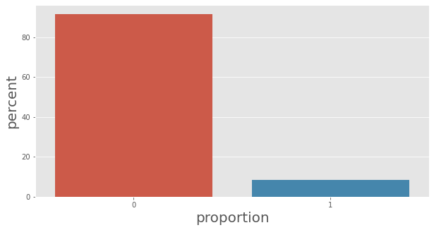

```python
df['main'] = df.LastWorkingDate.notnull().astype(int)
df_plot = df['main'].value_counts(normalize=True) * 100
plt.figure(figsize=(10, 5))
sns.barplot(df_plot.index, df_plot);
plt.xlabel('proportion', fontsize=20);
plt.ylabel('percent', fontsize=20)
```

**we created a dependent variable main without null values plotted graph gives us a proportion of 9:1**

**checking duplicates**

```python
df.drop_duplicates(inplace=True)
df
```

|  | MMM-YY | Emp_ID | Age | Gender | City | Education_Level | Salary | Dateofjoining | LastWorkingDate | Joining Designation | Designation | Total Business Value | Quarterly Rating | main |
| --- | --- | --- | --- | --- | --- | --- | --- | --- | --- | --- | --- | --- | --- | --- |
| 0 | 2016-01-01 | 1 | 28 | Male | C23 | Master | 57387 | 2015-12-24 | NaN | 1 | 1 | 2381060 | 2 | 0 |
| 1 | 2016-02-01 | 1 | 28 | Male | C23 | Master | 57387 | 2015-12-24 | NaN | 1 | 1 | -665480 | 2 | 0 |
| 2 | 2016-03-01 | 1 | 28 | Male | C23 | Master | 57387 | 2015-12-24 | 2016-03-11 | 1 | 1 | 0 | 2 | 1 |
| 3 | 2017-11-01 | 2 | 31 | Male | C7 | Master | 67016 | 2017-11-06 | NaN | 2 | 2 | 0 | 1 | 0 |
| 4 | 2017-12-01 | 2 | 31 | Male | C7 | Master | 67016 | 2017-11-06 | NaN | 2 | 2 | 0 | 1 | 0 |
| ... | ... | ... | ... | ... | ... | ... | ... | ... | ... | ... | ... | ... | ... | ... |
| 19099 | 2017-08-01 | 2788 | 30 | Male | C27 | Master | 70254 | 2017-06-08 | NaN | 2 | 2 | 740280 | 3 | 0 |
| 19100 | 2017-09-01 | 2788 | 30 | Male | C27 | Master | 70254 | 2017-06-08 | NaN | 2 | 2 | 448370 | 3 | 0 |
| 19101 | 2017-10-01 | 2788 | 30 | Male | C27 | Master | 70254 | 2017-06-08 | NaN | 2 | 2 | 0 | 2 | 0 |
| 19102 | 2017-11-01 | 2788 | 30 | Male | C27 | Master | 70254 | 2017-06-08 | NaN | 2 | 2 | 200420 | 2 | 0 |
| 19103 | 2017-12-01 | 2788 | 30 | Male | C27 | Master | 70254 | 2017-06-08 | NaN | 2 | 2 | 411480 | 2 | 0 |

19104 rows × 14 columns

```python
df.Emp_ID.nunique(), df['MMM-YY'].min(),df['MMM-YY'].max()
```

```
(2381, '2016-01-01', '2017-12-01')
```

**we have data of 2381 employees from starting date 2016-01-01 to end date of 2017-12-01**

*`Dropping Some Unimportant Columns*

```python
df.drop(['Joining Designation','Designation'],axis=1, inplace=True)
```

**creating histogram for age&salary columns to compare it with the normal distribution**

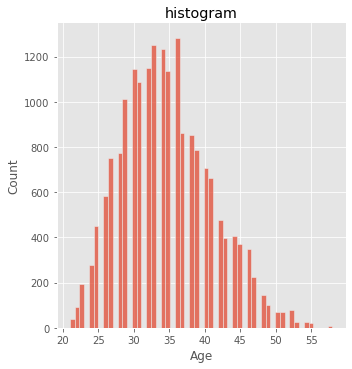

```python
sns.displot(df.Age, kind='hist')
plt.title('histogram');
```

*histogram is almost similar to a normal distribution*

```python
print('The mean of the age is: %.2f and the median is: %i' %(df.Age.mean(),df.Age.median()))
```

```
The mean of the age is: 34.65 and the median is: 34
```

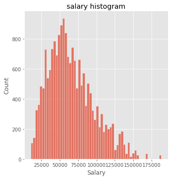

```python
sns.displot(df.Salary, kind='hist')
plt.title('salary histogram');
```

*salary histogram is skewed to the right*

**so lets check the mean and median for salary as it is positively skewed**

```python
print('The mean of the salary is: %i and the median is: %i' %(df.Salary.mean(),df.Salary.median()))
```

```
The mean of the salary is: 65652 and the median is: 60087
```

**The difference is off by 5000 USD**

lets observe how gender column is affecting the attrition

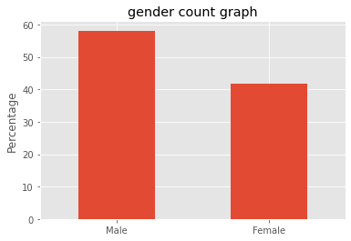

```python
(df.Gender.value_counts(normalize=True)*100).plot.bar(rot=0, title='gender count graph')
plt.ylabel('Percentage');
```

*we can observe that there are more males than females*

*conclusion from the above graph is that there is a difference of 16%*

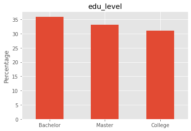

```python
#lets observe how education column is affecting the attrition
(df.Education_Level.value_counts(normalize=True)*100).plot.bar(rot=0, title='edu_level')
plt.ylabel('Percentage');
```

They have almost similar proportion at the education level

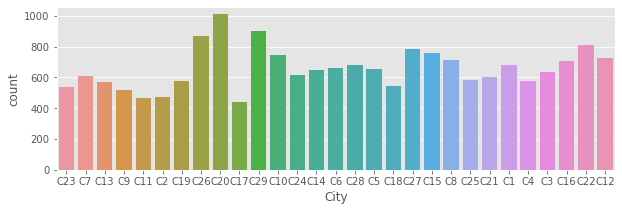

```python
df.City.nunique()
plt.figure(figsize=(10,3))
sns.countplot(data=df,x='City')
```

*We have 29 different cities and sufficient variance on each category*

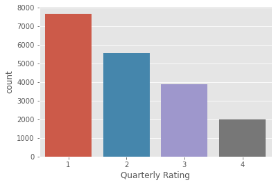

```python
sns.countplot(data=df,x='Quarterly Rating')
```

*we can observe that quarterly rating is decreasing gradually*

```python
df.groupby('main')['Quarterly Rating'].value_counts().unstack()
```

| Quarterly Rating main | 1 | 2 | 3 | 4 |
| --- | --- | --- | --- | --- |
| 0 | 6247 | 5407 | 3867 | 1967 |
| 1 | 1432 | 146 | 28 | 10 |

# Now we know how our data is, our next job is to describe the relationship with the main variable

*to select categorical columns and numerical columns we are using*

```python
 cat_cols = ['Gender','City','Education_Level']
num_cols = ['Age','Salary', 'Total Business Value']
```

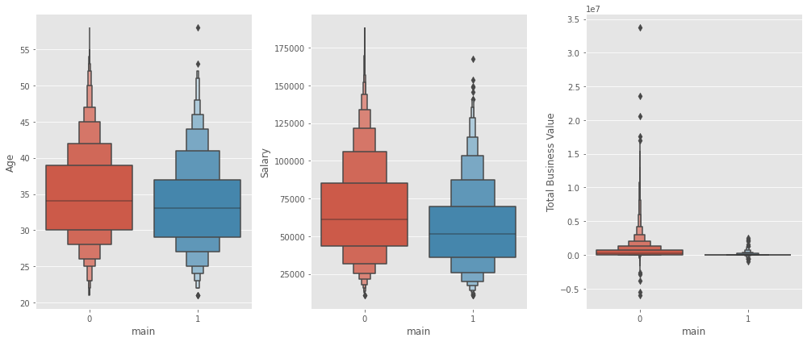

```python
plt.figure(figsize=(14,6))
for idx,col in enumerate(num_cols):
    df_temp = df[['main']+[col]]
    plt.subplot(1,3,idx+1)
    sns.boxenplot(data=df_temp,x='main',y=col)
    plt.tight_layout()
```

*for total business value we see a lot of outliers*

# We can observe that young employees and also employees with low salary have a little more chance to quit his job

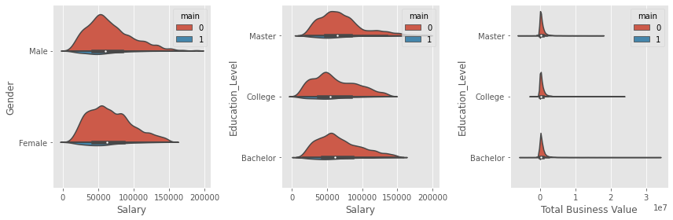

```python
plt.figure(figsize=(12,4))
plt.subplot(1,3,1)
sns.violinplot(data=df, y='Gender', x='Salary', hue='main', split=True, scale='count')
plt.subplot(1,3,2)
sns.violinplot(data=df, y='Education_Level', x='Salary', hue='main', split=True, scale='count')
plt.subplot(1,3,3)
sns.violinplot(data=df, y='Education_Level', x='Total Business Value', hue='main', split=True, scale='count')
plt.tight_layout()
```

*we have plotted our graphs in such a way that we have compared it with our main value and the positive cases proportions is low,we cannot see a great difference*

# but in the majority we can observe that master degree could help an employee to get a better salary.

*The employee has moved out?*

**The employee has change his Education level?**

*How many months have the same salary the employee?*

**categorical time date of joining date.**

*Dummy variables of categorical data leaving one category out*

# **Visualization**

```python
df['main'].value_counts()
```

```
0    17488
1     1616
Name: main, dtype: int64
```

```python
from sklearn.utils import resample
df_1 = df[df['main']==0]
df_2 = df[df['main']==1]

df_2_upsampled = resample(df_2,
                                 replace=True,     # sample with replacement
                                 n_samples=17488,    # to match majority class
                                 random_state=123) # reproducible results

# Combine majority class with upsampled minority class
df_upsampled = pd.concat([df_1, df_2_upsampled])

# Display new class counts
df_upsampled.main.value_counts()
```

```
0    17488
1    17488
Name: main, dtype: int64
```

```python
df_upsampled
```

|  | MMM-YY | Emp_ID | Age | Gender | City | Education_Level | Salary | Dateofjoining | LastWorkingDate | Total Business Value | Quarterly Rating | main |
| --- | --- | --- | --- | --- | --- | --- | --- | --- | --- | --- | --- | --- |
| 0 | 2016-01-01 | 1 | 28 | Male | C23 | Master | 57387 | 2015-12-24 | NaN | 2381060 | 2 | 0 |
| 1 | 2016-02-01 | 1 | 28 | Male | C23 | Master | 57387 | 2015-12-24 | NaN | -665480 | 2 | 0 |
| 3 | 2017-11-01 | 2 | 31 | Male | C7 | Master | 67016 | 2017-11-06 | NaN | 0 | 1 | 0 |
| 4 | 2017-12-01 | 2 | 31 | Male | C7 | Master | 67016 | 2017-11-06 | NaN | 0 | 1 | 0 |
| 5 | 2016-12-01 | 4 | 43 | Male | C13 | Master | 65603 | 2016-12-07 | NaN | 0 | 1 | 0 |
| ... | ... | ... | ... | ... | ... | ... | ... | ... | ... | ... | ... | ... |
| 4551 | 2016-09-01 | 680 | 37 | Female | C3 | Master | 127380 | 2011-07-28 | 2016-09-22 | 331570 | 1 | 1 |
| 11203 | 2017-11-01 | 1665 | 35 | Male | C12 | Bachelor | 52175 | 2017-04-26 | 2017-11-21 | 255480 | 2 | 1 |
| 16115 | 2017-10-01 | 2393 | 30 | Female | C27 | College | 87010 | 2017-08-08 | 2017-10-06 | 0 | 1 | 1 |
| 2856 | 2016-04-01 | 430 | 32 | Male | C28 | College | 14489 | 2016-01-06 | 2016-03-29 | 0 | 1 | 1 |
| 10307 | 2016-09-01 | 1536 | 27 | Male | C15 | Master | 39731 | 2016-07-19 | 2016-08-30 | 0 | 1 | 1 |

34976 rows × 12 columns

**After Upsampling**

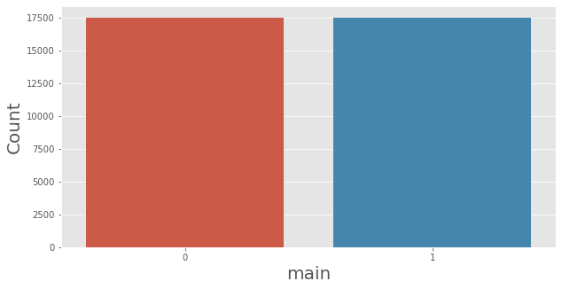

```python
status_label = df_upsampled.main.value_counts()
plt.figure(figsize=(10, 5))
sns.barplot(status_label.index, status_label);
plt.xlabel('main', fontsize=20);
plt.ylabel('Count', fontsize=20)
```

-->Classes are balanced

*Distribution of main based on City Name*

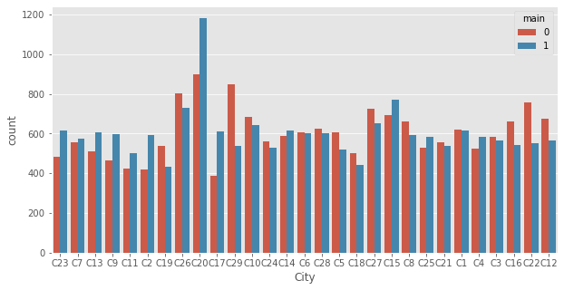

```python
plt.figure(figsize=(10, 5))
sns.countplot(x="City", hue="main", data=df_upsampled)
```

*Distribution of Age with respect to main*

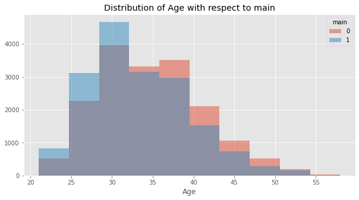

```python
plt.figure(figsize=(10, 5))
plt.hist("Age", data = df_upsampled[df_upsampled["main"] == 0], alpha = 0.5, label = "0")
plt.hist("Age", data = df_upsampled[df_upsampled["main"] == 1], alpha = 0.5, label = "1")
plt.title("Distribution of Age with respect to main")
plt.xlabel("Age")
plt.legend(title = "main")
plt.show()
```

# DATA PREPROCESSING

```python
df_upsampled.head()
```

|  | MMM-YY | Emp_ID | Age | Gender | City | Education_Level | Salary | Dateofjoining | LastWorkingDate | Total Business Value | Quarterly Rating | main |
| --- | --- | --- | --- | --- | --- | --- | --- | --- | --- | --- | --- | --- |
| 0 | 2016-01-01 | 1 | 28 | Male | C23 | Master | 57387 | 2015-12-24 | NaN | 2381060 | 2 | 0 |
| 1 | 2016-02-01 | 1 | 28 | Male | C23 | Master | 57387 | 2015-12-24 | NaN | -665480 | 2 | 0 |
| 3 | 2017-11-01 | 2 | 31 | Male | C7 | Master | 67016 | 2017-11-06 | NaN | 0 | 1 | 0 |
| 4 | 2017-12-01 | 2 | 31 | Male | C7 | Master | 67016 | 2017-11-06 | NaN | 0 | 1 | 0 |
| 5 | 2016-12-01 | 4 | 43 | Male | C13 | Master | 65603 | 2016-12-07 | NaN | 0 | 1 | 0 |

**City**

```python
city_name_label = {value: key for key, value in enumerate(df_upsampled['City'].unique())}
df_upsampled['City'] = df_upsampled['City'].map(city_name_label)
```

**education_level**

```python
Education_Level_label = {value: key for key, value in enumerate(df_upsampled['Education_Level'].unique())}
df_upsampled['Education_Level'] = df_upsampled['Education_Level'].map(Education_Level_label)
```

**salary**

```python
Salary_label = {value: key for key, value in enumerate(df_upsampled['Salary'].unique())}
df_upsampled['Salary'] = df_upsampled['Salary'].map(Salary_label)
```

**Gender**

```python
Gender_label = {value: key for key, value in enumerate(df_upsampled['Gender'].unique())}
df_upsampled['Gender'] = df_upsampled['Gender'].map(Gender_label)
```

**total business value**

```python
BusinessValue_label = {value: key for key, value in enumerate(df_upsampled['Total Business Value'].unique())}
df_upsampled['Total Business Value'] = df_upsampled['Total Business Value'].map(BusinessValue_label)
```

**quarterly rating**

```python
QuarterlyRating_label = {value: key for key, value in enumerate(df_upsampled['Quarterly Rating'].unique())}
df_upsampled['Quarterly Rating'] = df_upsampled['Quarterly Rating'].map(QuarterlyRating_label)
```

**main**

```python
main_label = {value: key for key, value in enumerate(df_upsampled['main'].unique())}
df_upsampled['main'] = df_upsampled['main'].map(main_label)
```

```python
df_upsampled.head()
```

|  | MMM-YY | Emp_ID | Age | Gender | City | Education_Level | Salary | Dateofjoining | LastWorkingDate | Total Business Value | Quarterly Rating | main |
| --- | --- | --- | --- | --- | --- | --- | --- | --- | --- | --- | --- | --- |
| 0 | 2016-01-01 | 1 | 28 | 0 | 0 | 0 | 0 | 2015-12-24 | NaN | 0 | 0 | 0 |
| 1 | 2016-02-01 | 1 | 28 | 0 | 0 | 0 | 0 | 2015-12-24 | NaN | 1 | 0 | 0 |
| 3 | 2017-11-01 | 2 | 31 | 0 | 1 | 0 | 1 | 2017-11-06 | NaN | 2 | 1 | 0 |
| 4 | 2017-12-01 | 2 | 31 | 0 | 1 | 0 | 1 | 2017-11-06 | NaN | 2 | 1 | 0 |
| 5 | 2016-12-01 | 4 | 43 | 0 | 2 | 0 | 2 | 2016-12-07 | NaN | 2 | 1 | 0 |

*Correlation Matrix*

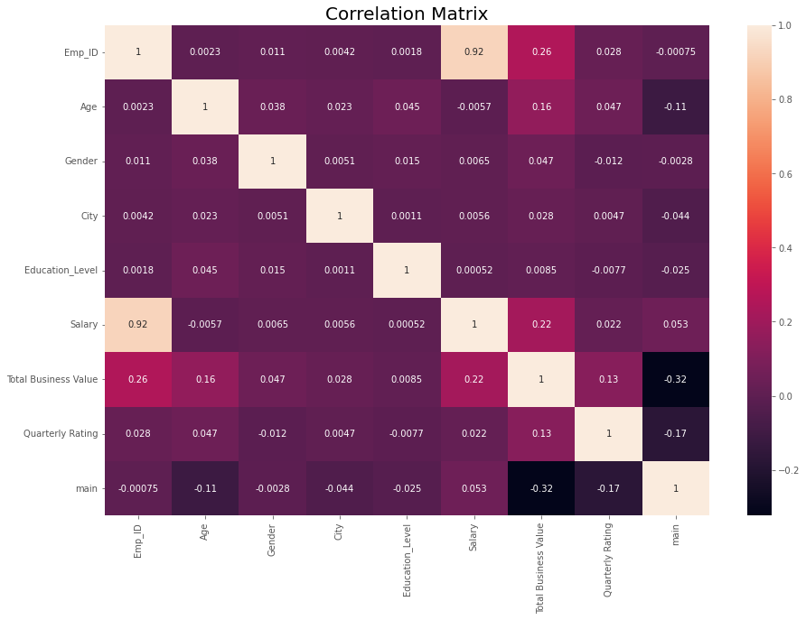

```python
plt.figure(figsize=(15, 10))
sns.heatmap(df_upsampled.corr(), annot=True);
plt.title('Correlation Matrix', fontsize=20);
```

*Checking the Correlation of main with repect to other features*

```python
df_upsampled.corr()['main'].sort_values(ascending=False)[1:]
```

```
Salary                  0.052602
Emp_ID                 -0.000748
Gender                 -0.002840
Education_Level        -0.024872
City                   -0.044360
Age                    -0.113846
Quarterly Rating       -0.173231
Total Business Value   -0.323274
Name: main, dtype: float64
```

```python
df_upsampled.head()
```

|  | MMM-YY | Emp_ID | Age | Gender | City | Education_Level | Salary | Dateofjoining | LastWorkingDate | Total Business Value | Quarterly Rating | main |
| --- | --- | --- | --- | --- | --- | --- | --- | --- | --- | --- | --- | --- |
| 0 | 2016-01-01 | 1 | 28 | 0 | 0 | 0 | 0 | 2015-12-24 | NaN | 0 | 0 | 0 |
| 1 | 2016-02-01 | 1 | 28 | 0 | 0 | 0 | 0 | 2015-12-24 | NaN | 1 | 0 | 0 |
| 3 | 2017-11-01 | 2 | 31 | 0 | 1 | 0 | 1 | 2017-11-06 | NaN | 2 | 1 | 0 |
| 4 | 2017-12-01 | 2 | 31 | 0 | 1 | 0 | 1 | 2017-11-06 | NaN | 2 | 1 | 0 |
| 5 | 2016-12-01 | 4 | 43 | 0 | 2 | 0 | 2 | 2016-12-07 | NaN | 2 | 1 | 0 |

# Binary Classification

*Here. 5 Classification Models are used in order to perform Binary Classification. The models used are:*

**1)Logistic Regression**

**2)K-Nearest Neighbours Classifier**

**3)Random Forest Classifier**

**4)Gaussian Naive Bayes Classifier**

**5)Decision Tree Classifier**

*The Classification Report, Confusion Matrix and Evaluation Metrics Accuracy, F1 Score and ROC-AUC Score are* *checked for each Classifier and are compared in order to decide which Classification Model is the best.*

```python
from sklearn.model_selection import train_test_split
from sklearn.linear_model import LogisticRegression
from sklearn.neighbors import KNeighborsClassifier
from sklearn.ensemble import RandomForestClassifier
from sklearn.naive_bayes import GaussianNB
from sklearn.tree import DecisionTreeClassifier
from sklearn.preprocessing import StandardScaler
from sklearn.metrics import accuracy_score, f1_score, confusion_matrix,recall_score, classification_report, roc_auc_score,roc_curve,auc
```

```python
accuracy_list = []
f1_list = []
roc_auc_list = []
recall_list = []
```

**Train Test Evaluation Function**

```python
def result(X, y, ts, rs, model):

    #train test split
    X_train, X_test, y_train, y_test = train_test_split(X, y, test_size=ts, random_state=rs)

    #scaling
    sc = StandardScaler()
    X_train = sc.fit_transform(X_train)
    X_test = sc.transform(X_test)

    #fit on data
    model.fit(X_train, y_train)

    #prediction
    pred = model.predict(X_test)

    #performance of model
    print("Classification Report: \n", classification_report(y_test, pred))
    print("-" * 100)
    print()

    #accuracy of model
    acc = accuracy_score(y_test, pred)
    accuracy_list.append(acc)
    print("Accuracy Score: ", acc)
    print("-" * 100)
    print()

    #recall
    recall = recall_score(y_test, pred)
    recall_list.append(recall)
    print("recall Score: ", recall)
    print("-" * 100)
    print()

    #f1-score of model
    f1 = f1_score(y_test, pred)
    f1_list.append(f1)
    print("F1 Score: ", f1)
    print("-" * 100)
    print()

    #roc-auc curve of model
    fpr,tpr,threshold = roc_curve(y_test,pred)
    auc_value = auc(fpr,tpr)
    rocauc_score = roc_auc_score(y_test, pred)
    roc_auc_list.append(rocauc_score)
    plt.figure(figsize=(5,5),dpi=100)
    print("ROC-AUC Score: ", f1)
    print("-" * 100)
    print()
    plt.plot(fpr,tpr,linestyle='-',label = "(auc_value = %0.3f)" % auc_value)
    plt.xlabel('False Positive Rate')
    plt.ylabel('True Positive Rate')
    plt.legend()
    plt.show()
    print()

    #confusion matrix for model
    print("Confusion Matrix: ")
    plt.figure(figsize=(10, 5))
    sns.heatmap(confusion_matrix(y_test, pred), annot=True, fmt='g');
    plt.title('Confusion Matrix', fontsize=20)
```

*Independent and Dependent Features*

```python
x = df_upsampled[['Emp_ID','Age','Gender','City','Education_Level','Salary','Total Business Value','Quarterly Rating']]
y = df_upsampled[['main']]
```

# LogisticRegression

[output not shown]

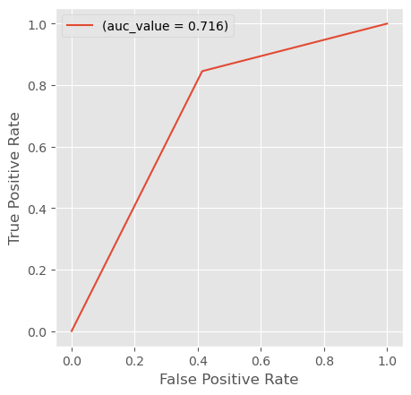

```
Confusion Matrix:
```

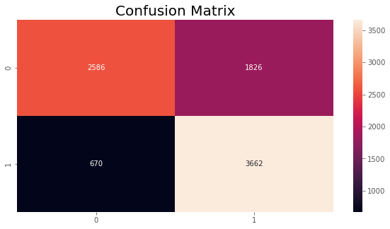

```python
model = LogisticRegression()
result(x, y, 0.25, 42, model)
```

**the harmonic mean of precision and recall ie f1 score for logistic regression is 0.7458**

**accuracy score for this model is 0.714**

# RANDOM FOREST

[output not shown]

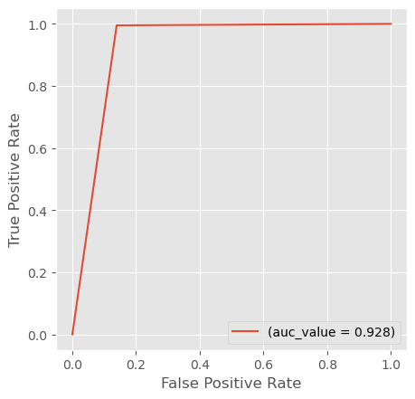

```
Confusion Matrix:
```

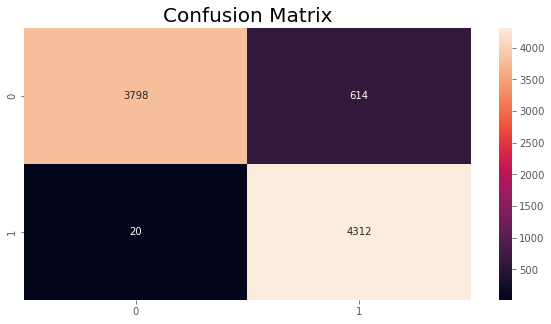

```python
rf = RandomForestClassifier()
result(x, y, 0.25, 42, rf)
```

# KNN Classifier

[output not shown]

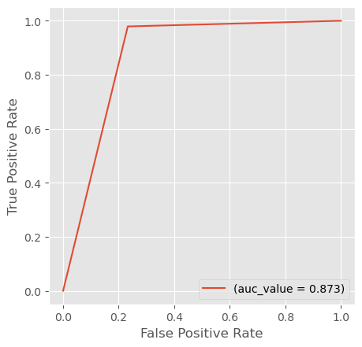

```
Confusion Matrix:
```

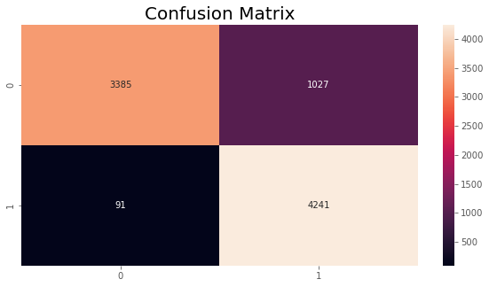

```python
knn = KNeighborsClassifier()
result(x, y, 0.25, 42, knn)
```

*knn classifier has an accuracy of 0.87 and f1 score is 0.88*

# Gaussian Naive Bayes

[output not shown]

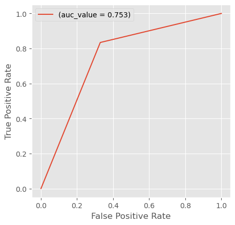

```
Confusion Matrix:
```

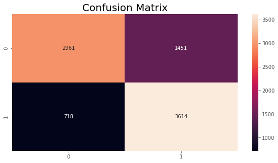

```python
nb = GaussianNB()
result(x, y, 0.25, 42, nb)
```

**Gaussian Naive Bayes model has an Accuracy Score: 0.75 and F1 Score: 0.76**

# DECISION TREE

[output not shown]

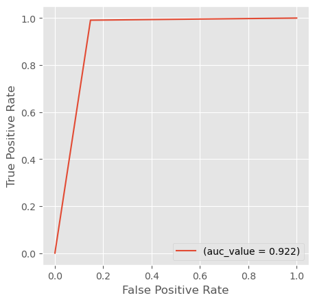

```
Confusion Matrix:
```

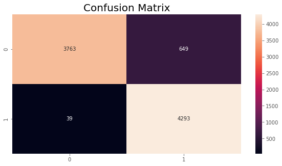

```python
dt = DecisionTreeClassifier()
result(x, y, 0.25, 42, dt)
```

**DECISION TREE model has an Accuracy Score: 0.92 and F1 Score: 0.925**

# Classifier Comparison

```python
classifier_list = ["Logistic Regression", "Random Forest", "KNN", "Naive Bayes", "Decision Tree"]
list_class = []
for i in range(0, len(classifier_list)):
  listclass = [classifier_list[i], accuracy_list[i],recall_list[i], f1_list[i], roc_auc_list[i]]
  list_class.append(listclass)

list_class
```

```
[['Logistic Regression',
  0.7145471180237878,
  0.84533702677747,
  0.7458248472505092,
  0.715732883289007],
 ['Random Forest',
  0.9274931381518756,
  0.9953831948291783,
  0.9315186865413696,
  0.9281086418388865],
 ['KNN',
  0.8721408966148216,
  0.9789935364727609,
  0.8835416666666666,
  0.8731096422164348],
 ['Naive Bayes',
  0.7519441903019213,
  0.8342566943674977,
  0.7691816537192722,
  0.7526904505382366],
 ['Decision Tree',
  0.9213174748398902,
  0.9909972299168975,
  0.9258141039465171,
  0.9219492042603527]]
```

```python
cc_table = pd.DataFrame(list_class, columns = ["Classifier", "Accuracy","recall", "F1 Score", "ROC-AUC Score"])
cc_table.sort_values(ascending = False, by = "Accuracy")
```

|  | Classifier | Accuracy | recall | F1 Score | ROC-AUC Score |
| --- | --- | --- | --- | --- | --- |
| 1 | Random Forest | 0.927493 | 0.995383 | 0.931519 | 0.928109 |
| 4 | Decision Tree | 0.921317 | 0.990997 | 0.925814 | 0.921949 |
| 2 | KNN | 0.872141 | 0.978994 | 0.883542 | 0.873110 |
| 3 | Naive Bayes | 0.751944 | 0.834257 | 0.769182 | 0.752690 |
| 0 | Logistic Regression | 0.714547 | 0.845337 | 0.745825 | 0.715733 |

*Plotting the Comparison Table as a Bar Plot For Accuracy*

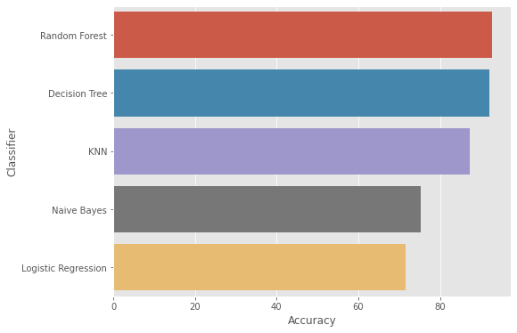

```python
plt.figure(figsize = (8,6))
sns.barplot(x = cc_table["Accuracy"]*100,
            y = cc_table["Classifier"],
            data = cc_table,
            order = cc_table.sort_values("Accuracy", ascending = False).Classifier)
```

**For F1 Score**

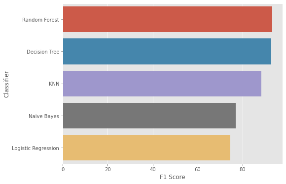

```python
plt.figure(figsize = (8,6))
sns.barplot(x = cc_table["F1 Score"]*100,
            y = cc_table["Classifier"],
            data = cc_table,
            order = cc_table.sort_values("F1 Score", ascending = False).Classifier)
```

**For ROC-AUC Score**

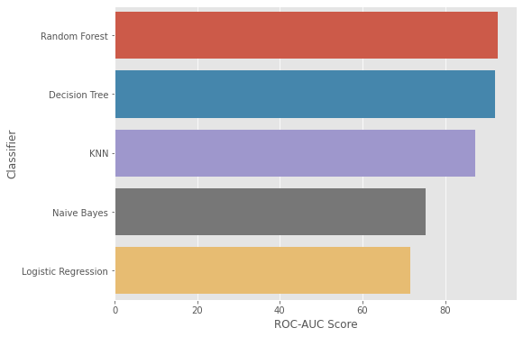

```python
plt.figure(figsize = (8,6))
sns.barplot(x = cc_table["ROC-AUC Score"]*100,
            y = cc_table["Classifier"],
            data = cc_table,
            order = cc_table.sort_values("ROC-AUC Score", ascending = False).Classifier)
```

*for recall score*

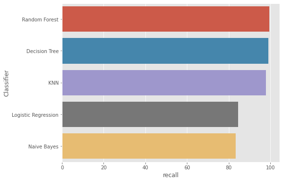

```python
plt.figure(figsize = (8,6))
sns.barplot(x = cc_table["recall"]*100,
            y = cc_table["Classifier"],
            data = cc_table,
            order = cc_table.sort_values("recall", ascending = False).Classifier)
```

# after comparing the evaluation metrics of each model we can conclude that the best classifier for our dataset is random forest. And decision tree classifier would be the next best option